# The distance dependence prediction of the Janzen‐Connell hypothesis: a meta‐analysis - Hyatt - 2003 - Oikos - Wiley Online Library

[Oikos](https://onlinelibrary.wiley.com/journal/16000706)

[Volume 103, Issue 3](https://onlinelibrary.wiley.com/toc/16000706/2003/103/3) p. 590-602

[figure not shown]

Full Access

# The distance dependence prediction of the Janzen-Connell hypothesis: a meta-analysis

[Laura A. Hyatt](https://onlinelibrary.wiley.com/action/doSearch?ContribAuthorStored=Hyatt%2C+Laura+A),

[Michael S. Rosenberg](https://onlinelibrary.wiley.com/action/doSearch?ContribAuthorStored=Rosenberg%2C+Michael+S),

[Timothy G. Howard](https://onlinelibrary.wiley.com/action/doSearch?ContribAuthorStored=Howard%2C+Timothy+G),

[Gregory Bole](https://onlinelibrary.wiley.com/action/doSearch?ContribAuthorStored=Bole%2C+Gregory),

[Wei Fang](https://onlinelibrary.wiley.com/action/doSearch?ContribAuthorStored=Fang%2C+Wei),

[Jean Anastasia](https://onlinelibrary.wiley.com/action/doSearch?ContribAuthorStored=Anastasia%2C+Jean),

[Kerry Brown](https://onlinelibrary.wiley.com/action/doSearch?ContribAuthorStored=Brown%2C+Kerry),

[Rebecca Grella](https://onlinelibrary.wiley.com/action/doSearch?ContribAuthorStored=Grella%2C+Rebecca),

[Katharine Hinman](https://onlinelibrary.wiley.com/action/doSearch?ContribAuthorStored=Hinman%2C+Katharine),

[Josepha P. Kurdziel](https://onlinelibrary.wiley.com/action/doSearch?ContribAuthorStored=Kurdziel%2C+Josepha+P),

[Jessica Gurevitch](https://onlinelibrary.wiley.com/action/doSearch?ContribAuthorStored=Gurevitch%2C+Jessica),

First published: 21 October 2003

https://doi.org/10.1034/j.1600-0706.2003.12235.x

Citations: 137

L. A. Hyatt, M. S. Rosenberg, T. G. Howard, G. Bole, W. Fang, J. Anastasia, K. Brown, R. Grella, K. Hinman, J. P.Kurdziel and J. Gurevitch, Dept of Ecology and Evolution, State Univ. of New York, Stony Brook, NY 11794-5245, USA (lhyatt@rider.edu). Present address for LAH: Dept of Biology, Rider Univ., Lawrenceville, NJ 08648, USA. Present address for MSR: Dept of Biology, Arizona State Univ., P.O. Box 871501, Tempe, AZ 85287-1501, USA. Present address for TGH: New York Natural Heritage Program, 625 Broadway, 5th Floor, Albany, NY 12233-4757, USA. Present address for BG: Univ. College of the Fraser Valley, 33844 King Rd, Abbotsford, Brittish Columbia, V2S 7M8 Canada. Present address for JA: Biology Dept, Ammerman Campus, Suffolk Community College, Smithtown Science Building (T-104) 533 College Road, Selden, NY 11784-2899, USA. Present address forRG: Aiza Biby, P.O. Box 701, East Setauket, NY 11733, USA. Present address for KH: Arizona Game and Fish Dept, Nongame Branch, 2221 W. Greenway Road WMNG, Phoenix, AZ 85023-4399, USA. Present address for JPK: Dept of Ecology and Evolutionary Biology, The Univ. of Michigan, Natural Science Building (Kraus), 830 North Univ., Ann Arbor, MI 48109-1048, USA.

## Abstract

Thirty years ago, two papers were published that proposed a suite of testable hypotheses about the processes maintaining diversity in tropical forests. At the time, it was thought that within a forest, individuals from each species of tropical tree were more regularly spaced than would be expected by a random process (Black et al. 1950, Pires et al. 1953) and that this facilitated the maintenance of high tree diversity. Janzen (1970) and Connell (1971) proposed that this pattern was the result of the interacting effects of clumped seed dispersal patterns focused on parent trees and the top-down effects of density- and distance-dependent behavior of seed, seedling and sapling predators. Under the hypothesis, recruitment only occurs under a small “population recruitment curve” (Janzen 1970) that is centered at some distance from parent trees. At this distance, seeds are available for germination and some germinating juveniles may survive. It was hypothesized that this process prevents the recruitment of offspring in close proximity to parent plants and promotes regular tree spacing. Of the five general predictions that Janzen made, the first was that the probability of survival of seeds to adulthood should increase with distance from the parent plant (Janzen 1970 p. 517, General prediction No. 1).

Connell (1971) further suggested that this effect should be stronger in seedlings than in seeds. His reasoning was that very few seeds are ever likely to survive, regardless of their location, given the multitude of processes that contribute to their deaths. However, insects and disease organisms with pathogenic effects on adults can have terminal, predatory effects on smaller seedlings with fewer resources to offset loss to damage. This process, he suggested, reduces the likelihood of offspring recruitment in areas of high surviving seed density which occur in close proximity to the parent and enhances regular spacing in tropical forests. He supported this contention with observational studies showing that seedlings located in clumps of conspecifics were less likely to survive than those in mixed species clumps. He also showed that the effect declined with increasing plant height (Connell 1971, Connell et al. 1984), suggesting that distance-dependent mortality is strongest at the seedling stage.

Does this process support species diversity in the same way everywhere? Janzen (1970) suggested that host specificity of seed consumers, herbivores and plant pathogens is greater in the tropics than it is in the temperate zone. Because a greater proportion of the temperate herbivore complex is composed of generalists (Harper 1977, Howe and Westley 1988) foraging should be less directed to specific targets. In contrast, the increased specificity of pathogens and predators should enhance the regular spacing of trees in the tropics. If true, this would predict that parental distance has a weaker effect on offspring survival in the temperate zone than in the tropics.

Howe and Smallwood (1982), whose work focused on plant population dynamics rather than overall community diversity, expanded on the idea that distance enhances survival, not just in the tropics, but in general. They suggested that not only does the distance a propagule moves from the parent enhance the probability of recruitment (escape hypothesis, a general form of prediction 4 of the Janzen-Connell hypothesis) but that propagule dispersal by trees to newly created forest gaps, which have both low adult density and altered seed predation probabilities, reduces the overall probability of juvenile predation (colonization hypothesis). Similarly, directed dispersal to habitats favoring seedling growth is also hypothesized to increase the chances of recruitment (directed dispersal hypothesis). Although targeted towards population rather than community dynamics, these ideas are components of the general predictions made by Janzen (1970). Data investigating these somewhat different hypotheses also contribute to an effective exploration of the distance-dependent component of the Janzen-Connell hypothesis.

The survival-enhancing effects of distance from parent plants have been explored by many researchers. The vast majority of tests have focused on single species, either experimentally examining how seed and seedling mortality rates change with distance from adults or comparing mortality rates between adjacent environments (e.g. intact forest and gaps or open fields). Such experimental and observational tests have taken place in both the tropical and temperate zones, and are designed to explore influences on the distribution of adult plants within a community. The studies have explored survival patterns for trees as well as shrubs and herbs and vary widely in duration and experimental seed or seedling density. All these factors may contribute to variation in the effect of distance on propagule survival.

Syntheses of the results from these numerous studies have met with mixed results. Clark and Clark (1984) tallied the numbers of studies that supported either density-dependent or distance-dependent components of the hypothesis and concluded that both components were supported. Willson (1988), examining the Howe and Smallwood (1982) escape hypothesis, compared seed mortality in intact and exposed or disturbed habitats for a variety of species and found virtually no patterns in seed predation intensity in either temperate or tropical habitats. Given the differing conclusions that these approaches have yielded, it is clear that a different strategy is required to explore the validity of this component of the Janzen-Connell hypothesis.

Meta-analysis is an emerging statistical tool in the ecological sciences that facilitates synthesizing the research results of multiple empirical studies that explore the same general question (Gurevitch and Hedges 1993, Arnquist and Wooster 1995). By devising a metric to summarize experimental results across many different experiments, meta-analyses statistically explore the magnitude of support for the hypothesis under consideration. Thus the technique is superior to traditional vote-counting methods because it makes it possible to generalize results across experiments and systems and quantify the magnitude of particular ecological effects, such as how strongly distance from parent influences propagule survival or how the magnitude of the effect differs across functional groups. Meta-analysis is quantitative, objective and embraces the inherent variation present in most ecological processes.

Some workers have objected to the application of meta-analysis because its results are confounded by publication bias; it has been shown in some settings that studies showing significant results are more likely to be published than those not showing significant results (Csada et al. 1996, but see Bachau 1997). However, it is possible to explore publication bias within data sets for meta-analysis using a variety of graphical, modeling and statistical techniques. These approaches allow for quantification of bias if it exists.

The distance aspect of the Janzen-Connell hypothesis is very amenable to testing through meta-analysis for several reasons. There are a large number of experiments in the literature addressing whether distance enhances propagule survival using a wide variety of plants. The spatial patterns of seed and seedling predation and survival have been explored from both animal and plant perspectives, exploring many independent hypotheses and reducing the potential for publication bias. Further, because this group of experiments is so large, excluding data sets with incomplete details (missing N, variance, replication) or poor design does not reduce the number of experiments included below a useful level. This situation is ideal for exploring the hypothesis as well as axillary, related questions.

Our primary objective was to use meta-analysis to examine the hypothesis that seed and seedling survival is enhanced with increasing distance from parent plants. Because we included studies considering distance from parent plants both literally, in terms of meters from a target parent plant, and figuratively, comparing survival of seeds in a habitat where adults are found (often under intact plant canopies) to one where adults are less dense (often in gaps or adjacent fields), we were able to examine the relative magnitude of support for the escape hypothesis with that for the colonization and directed dispersal hypotheses. We also compared the magnitude of this effect on seeds and seedlings, in the temperate and tropical zones, and on different life forms (trees, shrubs and herbaceous species). A regression approach was used to explore the effects that distance from parent plant (in meters), experimental propagule density, and study duration had on propagule survival. We also examined the role that publication bias might have in altering our conclusions.

## Methods

### Literature search

We chose ten major journals that we expected to publish field experiments on seed and seedling predation. We examined issues of the American Journal of Botany, American Midland Naturalist, American Naturalist, Biotropica, Canadian Journal of Botany, Ecology, Journal of Ecology, Journal of Tropical Ecology, Oecologia, and Oikos published between 1970 and 1998 for appropriate articles. Internet searches were also conducted using online versions of the Science Citation Index and Biological Abstracts, searching for the terms “seed” or “seedling” and “predation.” This search led to a large number of articles that were then examined for suitability of inclusion in the meta-analysis.

Criteria were devised a priori to avoid personal bias in selecting articles. Articles were included if all criteria applied to at least one experiment reported. For inclusion, the study had to be quantitative and the data reported in a usable form, allowing us to compute the number of seeds or seedlings surviving in each distance category and the number of seeds used in the test. Often, data were only reported in graphical form. To use these data, graphs were scanned with Deskscan II cx v 2.0 (Hewlett-Packard Co. 1993) software and analyzed with the data-grabbing software TechDig v1.1b (Jones 1995). Further, some experimental manipulation by the observer was required; experiments conducted with natural seedfall or naturally occurring seedlings were excluded. Studies had to report at least two contrasting conditions, either near/far from parent plant (“distance”), or two habitats with conspecific adults present in one habitat but generally not in the other (“habitat”). We also required studies to be conducted on native plants in their natural habitat and to use experimental designs that allowed predation on propagules by the full complement of native animals. This led us to reject data from portions of experiments that excluded groups of predators (insect or vertebrate exclosures) or only examined the effects of disease or pathogens on propagule survival.

### Data analysis

Experimenters generally placed a known number of propagules in depots which were located either near or far from the parent plant. After a given amount of time had passed, the number of survivors was counted and recorded. The number of individuals consumed was then inferred through subtraction. Thus, the data from each study can be arranged in a 2×2 contingency table, with columns corresponding to distance (near or far), and rows corresponding to seed or seedling fate (survival or predation, see Fig. 1). For studies involving multiple distances, we compared the closest and furthest depots and for studies with repeated measurements, we used a collective measure, selecting the number of individuals surviving and consumed at the final census interval as the values for the contingency table. The closest (near) depots were usually within the canopy of the focal plant, while the far distances were as noted in Appendix 1.

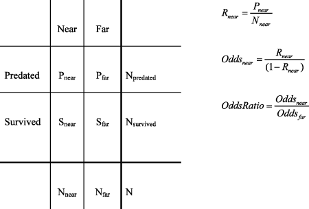

**Figure 1**

We believe this to be the first use of the odds ratio as a metric in meta-analysis in ecology. The odds ratios were calculated using the Mantel-Haenszel procedure (Mantel and Haenszel 1959, Yusuf et al. 1985), and studies were combined using traditional meta-analysis methodology (Rosenberg et al. 2000). Although there were many different metrics we could have chosen to calculate from our contingency tables (rate differences, rate ratios, or odds ratios; Berlin et al. 1989, Normand 1999, Rosenberg et al. 2000), we chose the odds ratio because it is a common metric in the medical meta-analysis literature and seemed to best represent the type of comparison we wished to make.

All of the analyses was conducted using MetaWin (Rosenberg et al. 2000). For specific details on meta-analysis and its calculations, see Hedges and Olkin (1985), Gurevitch and Hedges (1993), and Rosenberg et al. (2000). Mean effect sizes were calculated using a random-effects model (Raudenbush 1994, Hedges and Vevea 1998); we felt the fixed-effects model assumption that all observed variation is due to sampling error was unrealistic for such a broad based meta-analysis. Their confidence intervals were calculated using bootstrap resampling procedures as described in Adams et al. (1997).

We examined the heterogeneity of effect sizes using Q statistics (Hedges and Olkin 1985), which are essentially weighted sums of squares which follow a χ<sup>2</sup> distribution. The corresponding P-value indicates whether the variance among effect sizes is greater than would be expected from chance. For our categorical tests (seeds vs seedlings, tropical vs temperate, etc.), we examined the P-values associated with Q<sub>Between</sub>, which describes the variation in effect size between groups. The effects of continuous independent variables such as study duration, distance, and depot size on effect size were explored using a weighted least squares regression adjusted for meta-analysis (Hedges and Olkin 1985, Greenland 1987, Rosenberg et al. 2000). Because in meta-analysis the standard errors of the slope and intercept cannot be determined through normal least squares procedures, different formulas are required to adjust the weighted least squares regression (Hedges and Olkin 1985).

The possibility of publication bias was explored through the examination of weighted histograms (Greenland 1987) and funnel plots (Light and Pillemer 1984, Palmer 1999). Publication bias occurs when studies showing significant results enjoy a greater possibility of publication than those showing non-significant results. If the distribution of a weighted histogram (where weight is the inverse of the variance of the effect size in each study) is depressed around 0, it suggests that a publication bias exists against publishing nonsignificant studies. A funnel plot, which graphs effect size against sample size or variance, can also indicate if bias exists in the data set if it is skewed in shape or direction. We also conducted Spearman rank correlation tests, examining the relationship between the standardized effect size and the sample size across studies (Begg 1994, Begg and Mazumdar 1994). Significance of such a test indicates that larger effect sizes in either direction are more likely to be published than smaller effect sizes.

## Results

After all available studies were examined for suitability, 40 papers remained, yielding 152 data points based on 75 unique species (Appendix 1). Some studies were rejected because they were not experimental or used non-native seeds in studies of mammal behavior. Others were rejected because it was not possible to obtain the needed data from the published material (missing N, numbers of surviving or consumed seeds). A third group of studies were rejected because they involved predispersal seed predation or explored the effects of varying parent density. Although these studies address aspects of the Janzen-Connell hypothesis, they did not relate to our question of interest. The retained studies were heavily weighted towards examining seed predation, with 129 data points derived from experimental data on seed survival. The remaining 23 data points concerned experimental seedling studies. One hundred and four of the data points were derived from studies conducted in the tropics, and the remainder were taken from temperate zone data. 82 data points were based on distance data and 70 were derived from experiments contrasting survival in different habitat types.

### Overall effect

There were no individual outliers or groups of points with significantly different effect sizes than all the data points together; i.e. the test of overall heterogeneity was not significant (Q<sub>total</sub>=152.21, P=0.45). The 95% confidence interval (corrected for bias introduced through resampling) for the mean effect size for all data points together significantly overlapped zero, suggesting that, on average, across all studies, distance from parent plant does not enhance propagule survival (Fig. 2).

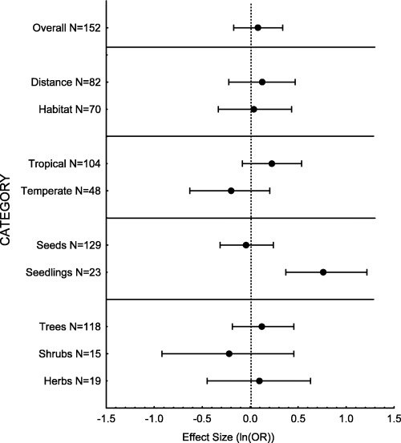

**Figure 2**

Confidence intervals for study categories. Points show means and bars show 95% bias-corrected confidence interval ranges for all studies as well as each study category. Sample sizes and categories indicated on figure; dotted line shows ln(OR)=0, indicating the absence of an effect.

### Distance versus habitats

Studies that explicitly tested the effect of distance on survival showed no significant effect of distance (average effect=0.13, Fig. 2). Studies that tested the effect of habitat also had no effect (average effect=0.04, Fig. 2). Further, the mean effect sizes for the two sub-sets did not significantly differ from each other (Q<sub>between</sub>=0.13, P=0.71) and they did not differ in any of the subsequent analyses (data not reported). For this reason, results below are reported for the distance and habitat sets combined.

### Temperate versus tropical

The tropical and temperate sub-sets of the data set did not have average effect sizes that significantly differed from each other, or from 0 (Q<sub>between</sub>=2.62, P=0.10, Fig. 2). However, examination of the means and confidence intervals (Fig. 2) suggests that propagules of tropical species may show a slight tendency for increased probability of survival at a distance from parent plants (average effect=0.23) and temperate propagules may show slight tendency for decreased survival with distance from parent plants (average effect=−0.2).

### Seeds versus seedlings

For seeds, there was no effect of distance on survival but for seedlings, distance appeared to have a positive effect on survival (predation was higher near the parent, average effect=0.76, Fig. 2). The mean effects on seeds and seedlings were significantly different from each other (Q<sub>between</sub>=5.07, P=0.024).

### Life forms

There was no detectable effect of distance on propagule survival for trees, shrubs or herbs (Q<sub>between</sub>=0.66, P=0.71). Further, the mean effects for any of the groups did not differ significantly from 0 (Fig. 2). Thus, the inclusion of non-tree species (n=15 for shrubs, n=19 for herbs) did not mask any effect that might be seen considering trees alone.

### Publication bias and mean effects

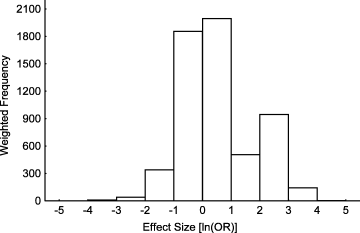

**Figure 3**

Histogram of effect aize values weighted by 1/variance. Based on 151 of the 152 studies; one study with an effect of −8.21 and a weight of 2.18 is not shown on this figure.

## Discussion

Still, the possibility remains that examining other subsets of the data or other predictions may yield more support for the hypothesis. When he originally posed the hypothesis, Janzen suggested that the pattern should be more apparent in species with regularly distributed adult populations than for those with random or clumped distributions (Janzen 1970, p. 517, General prediction No. 5). One would assume that studies purporting to test this aspect of the hypothesis would provide data on adult distributions, but such information is rarely provided. As we did not examine adult distributions, this factor, along with interannual timing and magnitude of reproduction (masting patterns) may have affected propagule survival in ways we did not detect. However, those factors were beyond the scope of this study.

These results do support the findings of workers who have explored the Janzen-Connell model mathematically. Implicit in the model is the idea that the existence of some minimum critical recruitment distance will necessarily lead to regular spacing of adult trees. Such a pattern was assumed to describe tropical forests at the time (Black et al. 1950, Pires et al. 1953), although many forests that have been examined explicitly are better described by random or clumped models than uniform ones (Condit et al. 1992, Wills et al. 1997, Hubbell et al. 1999).

Hubbell (1980) tested the potential role of distance-dependence in maintaining tree diversity through modeling and showed that spacing patterns can account for only a very small fraction of observed tree diversity. His model suggested that under this hypothesis, only a very few species could be maintained. Adding annual and interspecific variation in seed dispersal and recruitment to the model further increases heterogeneity in adult spacing, reducing the likelihood of regular species distributions sustaining excess diversity.

We were surprised to find that in general, offspring survivorship was not enhanced by moving to habitats at a distance from parents (Fig. 2; distance vs habitat; range for habitat findings not different from 0). Species selected for such studies would most likely be those suspected to enjoy some kind of benefit from moving to less shaded habitats than those occupied by their parents. Our finding suggests that at this scale, directed dispersal to gaps or adjacent but different habitats does not generally enhance recruitment. For individual species, specialization on gap environments may enhance fitness, but at this scale it is not possible to make general conclusions (Hubbell et al. 1999). Although directed dispersal may play a role in the dynamics of colonization by some ruderal, invading, or early successional species, on average, directed dispersal to gaps or other habitats did not significantly improve offspring survival.

The lack of an effect of distance on survival in tropical settings and a slight negative effect of distance on survival in the temperate zone suggests that Janzen's (1970) ideas about the specificity of granivores and herbivores in the two regions bear further examination. It should be noted that we were able to use only two studies of temperate zone seedling survival in our meta-analysis (Appendix 1), and thus these results pertain more strongly to granivory than herbivory. Studies of the interactions of foraging behavior of temperate zone seed predators and plant population dynamics may bear further examination.

Connell (1971) argued that if propagule distance or density were to impact diversity, it should be seen most strongly in individual species at the seedling stage. Our results (Fig. 2, seeds vs seedlings), combined with some recently reported data analysis from the Forest Dynamics Project in Panama on seedling density (Harms et al. 2000) support this contention. Clearly, because they grow larger, as seedlings age they are more detectable by visually-oriented specialist predators. Dense clumps of seedlings, often found at short distances from parent plants, are very apparent to specialist predators who cue on adults. As individuals within these clumps age and self-thin, not only are they less apparent to specialists, but they also have more resources to fend off the effects of herbivores and specialized pathogens.

The lack of significant differences among life forms is not surprising. There is no reason to suspect that tree seeds or seedlings of the same size are subject to different pressures or have different kinds of defenses from those of herbs or shrubs. However, correcting our analysis for seed size might reveal interesting trends. Although the original hypothesis was constructed to explain tree diversity, it could also explain the diversity of other life forms as well, albeit at different scales.

## Acknowledgements

This work was the product of a graduate seminar in Meta-analysis and is contribution No. 1109 from the program in Ecology and Evolution at the State University of New York at Stony Brook.

| Study | Authors and year | Env. | Life form | Stage | Dur. | Dens. | Dist. | Near total | Near No. surviving | Far total | Far No. surviving | ln OR | var ln OR |
| --- | --- | --- | --- | --- | --- | --- | --- | --- | --- | --- | --- | --- | --- |
| 1.1 | Augspurger and Kitajima 1992 | 1 | T | 1 | 77 | 10 | 100 | 7433.5 | 1963.8 | 588.6 | 245.9 | 0.770 | 0.009 |
| 1.2 | Augspurger and Kitajima 1992 | 1 | T | 1 | 77 | 10 | 100 | 7433.5 | 1432.4 | 588.6 | 188.3 | 0.790 | 0.011 |
| 1.3 | Augspurger and Kitajima 1992 | 1 | T | 1 | 77 | 10 | 100 | 1250 | 574.5 | 2500 | 857.9 | −0.493 | 0.005 |
| 1.4 | Augspurger and Kitajima 1992 | 1 | T | 1 | 77 | 6 | 100 | 4676.19 | 1969.4 | 611.92 | 148.0 | −0.745 | 0.008 |
| 1.5 | Augspurger and Kitajima 1992 | 1 | T | 1 | 77 | 6 | 100 | 4563.72 | 1773.2 | 541.19 | 88.9 | −0.965 | 0.009 |
| 1.6 | Augspurger and Kitajima 1992 | 1 | T | 1 | 77 | 6 | 100 | 750 | 319.7 | 1500 | 205.3 | −1.615 | 0.011 |
| 1.7 | Augspurger and Kitajima 1992 | 1 | T | 2 | 700 | 10 | 100 | 1963.84 | 278.4 | 245.96 | 37.8 | 0.107 | 0.037 |
| 1.8 | Augspurger and Kitajima 1992 | 1 | T | 2 | 700 | 10 | 100 | 1432.36 | 189.2 | 188.27 | 20.9 | −0.170 | 0.053 |
| 1.9 | Augspurger and Kitajima 1992 | 1 | T | 2 | 700 | 10 | 100 | 574.45 | 61.8 | 856.85 | 185.6 | 0.759 | 0.020 |
| 1.10 | Augspurger and Kitajima 1992 | 1 | T | 2 | 700 | 6 | 100 | 1969.43 | 107.7 | 147.986 | 23.7 | 1.832 | 0.123 |
| 1.11 | Augspurger and Kitajima 1992 | 1 | T | 2 | 700 | 6 | 100 | 1773.15 | 133.8 | 88.87 | 7.1 | 0.125 | 0.166 |
| 1.12 | Augspurger and Kitajima 1992 | 1 | T | 2 | 700 | 6 | 100 | 319.68 | 49.6 | 205.31 | 20.9 | −0.450 | 0.068 |
| 2.1 | Bermejo et al. 1998 | 2 | S | 1 | 4.5 | 50 |  | 1250 | 342.5 | 2500 | 725.0 | 0.078 | 0.006 |
| 2.2 | Bermejo et al. 1998 | 2 | S | 1 | 4.5 | 50 |  | 1250 | 567.5 | 2500 | 905.0 | −0.386 | 0.005 |
| 2.3 | Bermejo et al. 1998 | 2 | H | 1 | 4.5 | 50 |  | 1250 | 315.0 | 2500 | 490.0 | −0.332 | 0.007 |
| 3.1 | Boman and Casper 1995 | 2 | T | 1 | 21 | 1 |  | 24 | 7.1 | 24 | 0.0 | −2.048 | 0.579 |
| 3.2 | Boman and Casper 1995 | 2 | T | 1 | 24 | 1 |  | 24 | 16.4 | 24 | 1.2 | −2.552 | 0.336 |
| 3.3 | Boman and Casper 1995 | 2 | T | 1 | 21 | 1 |  | 24 | 3.0 | 24 | 0.0 | −1.606 | 1.054 |
| 3.4 | Boman and Casper 1995 | 2 | H | 1 | 21 | 3 |  | 72 | 5.2 | 72 | 35.4 | 2.015 | 0.133 |
| 3.5 | Boman and Casper 1995 | 2 | H | 1 | 24 | 3 |  | 72 | 1.4 | 72 | 49.7 | 2.866 | 0.119 |
| 3.6 | Boman and Casper 1995 | 2 | T | 1 | 21 | 2 |  | 48 | 9.9 | 48 | 2.1 | −1.385 | 0.351 |
| 3.7 | Boman and Casper 1995 | 2 | T | 1 | 24 | 2 |  | 48 | 43.3 | 48 | 4.1 | −3.169 | 0.162 |
| 3.8 | Boman and Casper 1995 | 2 | S | 1 | 21 | 5 |  | 120 | 10.3 | 120 | 56.2 | 1.876 | 0.082 |
| 3.9 | Boman and Casper 1995 | 2 | S | 1 | 24 | 5 |  | 120 | 35.5 | 120 | 89.3 | 1.773 | 0.066 |
| 3.10 | Boman and Casper 1995 | 2 | S | 1 | 21 | 1 |  | 24 | 16.5 | 24 | 0.0 | −2.842 | 0.345 |
| 3.11 | Boman and Casper 1995 | 2 | S | 1 | 24 | 1 |  | 24 | 21.0 | 24 | 3.6 | −2.745 | 0.314 |
| 4.1 | Burkey 1994 | 1 | T | 1 | 20 | 1 | 25 | 28 | 11.9 | 70 | 38.4 | 0.473 | 0.193 |
| 5.1 | Caccia and Ballare 1998 | 2 | T | 1 | 5 | 30 |  | 960 | 299.7 | 960 | 536.9 | 1.004 | 0.009 |
| 5.2 | Caccia and Ballare 1998 | 2 | T | 1 | 3 | 50 |  | 500 | 36.0 | 500 | 217.3 | 1.908 | 0.021 |
| 6.1 | Casper 1987 | 2 | H | 1 | 2 | 10 | 2.5 | 470 | 315.0 | 480 | 408.0 | 0.984 | 0.023 |

[output cut: 122 more lines]

[output not shown]

## Citing Literature

[figure not shown]

[Volume103, Issue3](https://onlinelibrary.wiley.com/toc/16000706/2003/103/3)

December 2003

Pages 590-602

### Metrics

Citations: 137

### Publication History

[Download PDF](https://onlinelibrary.wiley.com/doi/pdf/10.1034/j.1600-0706.2003.12235.x)